# Yours in the Fantasy Analysis: Week 9

## Total Wins Approach

This approach sums, for each week, how many other teams you would have beaten. A team’s expected win percentage is then calculated as the number of actual possible wins, divided by the maximum number of possible wins possible, 9*number of weeks.

| Team | Week Wins | Actual Wins | Expected Wins | Actual Wins - Expected Wins |
| --- | --- | --- | --- | --- |
| Kolin | 55 | 6 | 6.11 | -0.11 |
| Carter/Ale | 54 | 5 | 6 | -1 |
| Tex | 53 | 6 | 5.89 | 0.11 |
| Trainor | 41 | 3 | 4.56 | -1.56 |
| Cameron | 39 | 6 | 4.33 | 1.67 |
| Luke | 39 | 5 | 4.33 | 0.67 |
| KY | 38 | 2 | 4.22 | -2.22 |
| Rich | 33 | 5 | 3.67 | 1.33 |
| KB | 31 | 3 | 3.44 | -0.44 |
| Roland | 22 | 4 | 2.44 | 1.56 |

## Pythagorean Wins Analysis

This analysis tries to calculate expected wins as a function of points for, and a proxy for points against. The exponent used is 13.91.

| Team | Actual Wins | Expected Wins | Actual Wins - Expected Wins |
| --- | --- | --- | --- |
| Kolin | 6 | 7.81 | -1.81 |
| Carter/Ale | 5 | 7.35 | -2.35 |
| Tex | 6 | 6.8 | -0.8 |
| Cameron | 6 | 5.77 | 0.23 |
| Trainor | 3 | 4.27 | -1.27 |
| KY | 2 | 3.71 | -1.71 |
| Rich | 5 | 3.2 | 1.8 |
| KB | 3 | 2.37 | 0.63 |
| Luke | 5 | 2.31 | 2.69 |
| Roland | 4 | 0.75 | 3.25 |

## All Schedules Simulated

Our league is setup so that each team plays each of the other 9 teams once during the first 9 weeks of the season, and then replays the first 4 teams they played. There are 362,880 such possible schedules.

### Distribution of Wins over All Potential Schedules

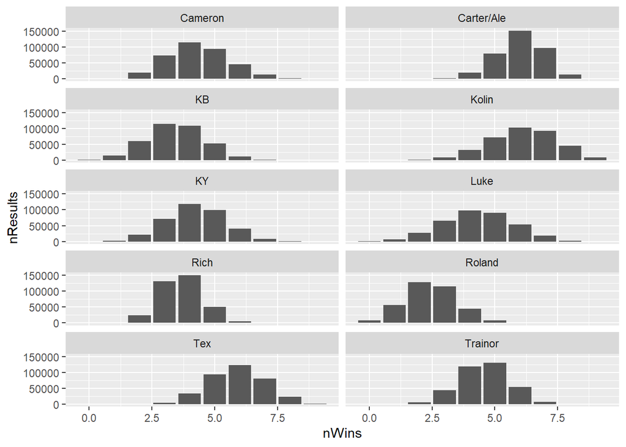

### Max and Min Wins Possible

This table shows, for each team, the maximum number of wins and the minimum number of wins that each team could have achieved over all possible schedules. It also shows out of the 362880 possible schedules, how many times a team achieves that number of wins.

| Team | Min Wins Possible | Max Wins Possible | # Min | # Max |
| --- | --- | --- | --- | --- |
| Kolin | 0 | 9 | 10 | 9334 |
| Tex | 3 | 9 | 4218 | 2106 |
| Luke | 0 | 9 | 552 | 153 |
| Cameron | 2 | 9 | 19958 | 106 |
| KY | 0 | 9 | 98 | 7 |
| Carter/Ale | 2 | 8 | 48 | 13056 |
| KB | 0 | 8 | 1114 | 12 |
| Trainor | 1 | 7 | 204 | 7068 |
| Rich | 1 | 6 | 1320 | 5520 |
| Roland | 0 | 6 | 8544 | 696 |

## Start/Sit Efficiency Analysis

### Optimal Records

This table contains each teams records if they and their opponent played their optimal lineups each week.

| Team | Optimal Lineup Wins | Actual Wins | Optimal - Actual Wins |
| --- | --- | --- | --- |
| Cameron | 6 | 6 | 0 |
| Carter/Ale | 5 | 5 | 0 |
| KB | 6 | 3 | 3 |
| Kolin | 4 | 6 | -2 |
| KY | 4 | 2 | 2 |
| Luke | 3 | 5 | -2 |
| Rich | 4 | 5 | -1 |
| Roland | 3 | 4 | -1 |
| Tex | 7 | 6 | 1 |
| Trainor | 3 | 3 | 0 |

### Average Points Left on Bench

| Team | Average Lost Points | Average Optimal Points | Average Points |
| --- | --- | --- | --- |
| Roland | 14.7 | 123.85 | 109.15 |
| Luke | 17.94 | 137.02 | 119.08 |
| KY | 20.07 | 144.77 | 124.7 |
| Tex | 20.99 | 158.19 | 137.2 |
| Trainor | 21.17 | 147.94 | 126.77 |
| Rich | 21.4 | 144.18 | 122.78 |
| Cameron | 21.46 | 153.94 | 132.48 |
| Kolin | 22.12 | 166.12 | 144 |
| Carter/Ale | 22.5 | 162.99 | 140.48 |
| KB | 31.84 | 151.21 | 119.36 |

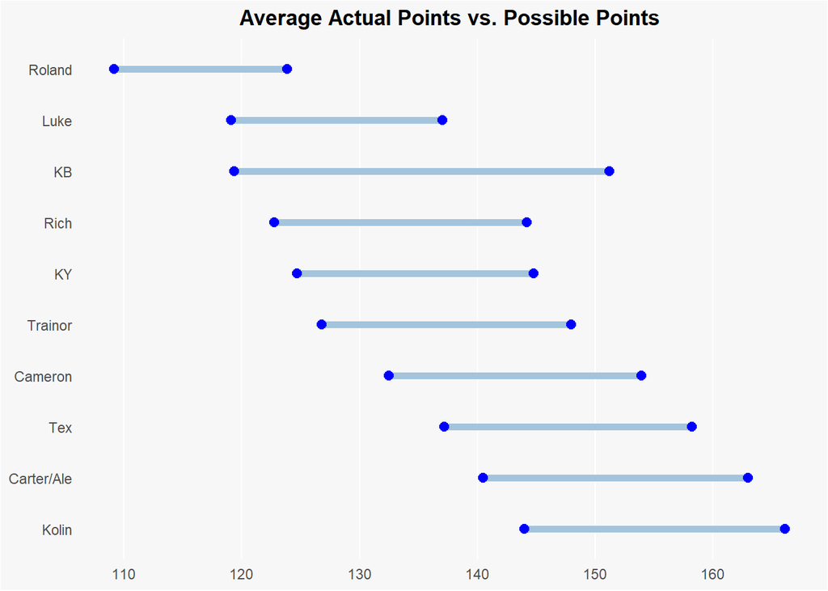

## Actuals vs Projections

This section of analysis concerns projections.

### Lineup Skill

This plot contains the average score of the user set lineup, and the average score of the lineup that was projected by ESPN to score the most each week.

[figure not shown]

### Who Follows Projections?

This table containst the number of times that each team played the lineup that was projected by ESPN to score the most each week.

| Team | Beat ESPN | Equal to ESPN | ESPN Better |
| --- | --- | --- | --- |
| Rich | 2 | 7 | 0 |
| Cameron | 1 | 5 | 3 |
| Tex | 2 | 5 | 2 |
| Luke | 1 | 4 | 4 |
| Carter/Ale | 0 | 3 | 6 |
| KY | 2 | 3 | 4 |
| Kolin | 5 | 2 | 2 |
| Roland | 4 | 2 | 3 |
| KB | 3 | 1 | 5 |
| Trainor | 4 | 1 | 4 |

### Optimal Lineup Records

This table contains each owners record if they started the lineup that was projected by ESPN to score the most each week.

| Team | ESPN Wins | Actual Wins | ESPN - Actual Wins |
| --- | --- | --- | --- |
| Carter/Ale | 6 | 5 | 1 |
| KB | 4 | 3 | 1 |
| Roland | 5 | 4 | 1 |
| Trainor | 4 | 3 | 1 |
| Cameron | 6 | 6 | 0 |
| KY | 2 | 2 | 0 |
| Rich | 5 | 5 | 0 |
| Tex | 6 | 6 | 0 |
| Kolin | 5 | 6 | -1 |
| Luke | 4 | 5 | -1 |

## Positional Strengths and Weaknesses

### Average Points by Position and Team

Note that a teams WR1/RB1 is the WR/RB each week that scored the most points.

| Owner | DST | FLEX | K | QB | RB1 | RB2 | TE | WR1 | WR2 | Total |
| --- | --- | --- | --- | --- | --- | --- | --- | --- | --- | --- |
| Kolin | 10 | 21.86 | 10.22 | 17.6 | 21.23 | 9.39 | 14.66 | 24.62 | 14.42 | 144 |
| Carter/Ale | 19.44 | 11.42 | 9.89 | 16.2 | 31.59 | 12.9 | 14.4 | 15.5 | 9.14 | 140.48 |
| Tex | 9.44 | 14.76 | 10.22 | 17.85 | 22.21 | 17.21 | 17.62 | 19.02 | 8.87 | 137.2 |
| Cameron | 12.89 | 19.32 | 7.89 | 19.47 | 19.07 | 12.03 | 7.11 | 23.37 | 11.33 | 132.48 |
| Trainor | 9.33 | 11.27 | 7.33 | 25.85 | 20.84 | 12.88 | 10.57 | 20.68 | 8.02 | 126.77 |
| KY | 5.67 | 11.82 | 8.44 | 20.18 | 20.38 | 10.73 | 12.67 | 23.91 | 10.9 | 124.7 |
| Rich | 10.56 | 11.8 | 6.56 | 22.34 | 19.11 | 8.37 | 6.04 | 23.02 | 14.98 | 122.78 |
| KB | 9.67 | 11.73 | 6.33 | 19.52 | 26.99 | 15.63 | 9.24 | 14.4 | 5.84 | 119.35 |
| Luke | 7.11 | 10.96 | 10.22 | 15.64 | 19.51 | 11.48 | 12.52 | 21.72 | 9.92 | 119.08 |
| Roland | 10.22 | 10.2 | 5.89 | 19.61 | 19.87 | 11.59 | 8.08 | 15.83 | 7.86 | 109.15 |

### Points Above Average by Position

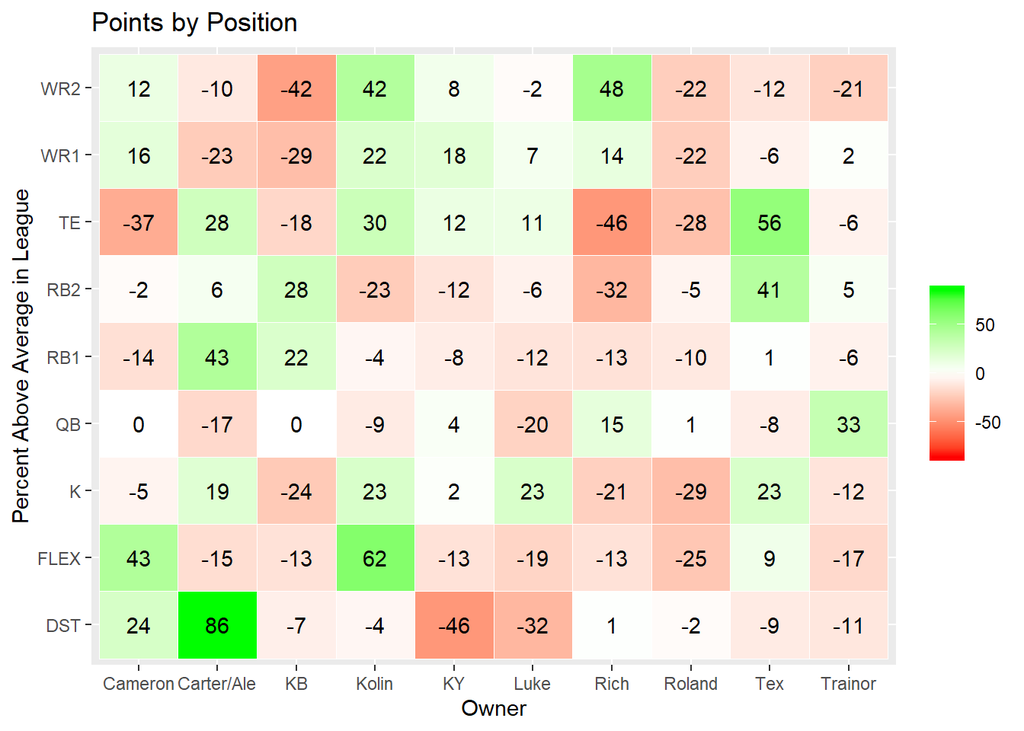

A work by [Luke Wilson](https://github.com/lvzwilson1/)

*lvzwilson@gmail.com*